# R Notebook of Mushroom Classification

David Stelzig

# Introduction

This is an R Notebook that demonstrates the basic analysis and classification of the mushroom dataset: Mushroom Dataset. (1981). UCI Machine Learning Repository. https://doi.org/10.24432/C5959T.

## Dataset

The data contain 23 characteristic features of different mushrooms, including odor, bruises and more. The main target feature is the **poisonous** class.

## Topics

The notebook includes the following steps:

- Import of libraries, loading the data and **cleaning** the data (missing values, near-zero variation features, useless columns, …)
- **Exploratory Data Analysis**
- **Training** of a Random Forest Model to classify mushrooms

# 1. Load Libraries and import the data

```r
library(tidyverse)
library(caret)
library(randomForest)
library(ggplot2)
library(DataExplorer)



mushroom_data <- read.csv("C:/Users/Sabrina/OneDrive/Desktop/David_work/R/mushrooms.csv")
head(mushroom_data)
```

|  | class | cap.shape | cap.surface | cap.color | bruises | odor | gill.attachment | gill.spacing | gill.size | gill.color | stalk.shape | stalk.root | stalk.surface.above.ring | stalk.surface.below.ring | stalk.color.above.ring | stalk.color.below.ring | veil.type | veil.color | ring.number | ring.type | spore.print.color | population | habitat |
| --- | --- | --- | --- | --- | --- | --- | --- | --- | --- | --- | --- | --- | --- | --- | --- | --- | --- | --- | --- | --- | --- | --- | --- |
| 1 | p | x | s | n | t | p | f | c | n | k | e | e | s | s | w | w | p | w | o | p | k | s | u |
| 2 | e | x | s | y | t | a | f | c | b | k | e | c | s | s | w | w | p | w | o | p | n | n | g |
| 3 | e | b | s | w | t | l | f | c | b | n | e | c | s | s | w | w | p | w | o | p | n | n | m |
| 4 | p | x | y | w | t | p | f | c | n | n | e | e | s | s | w | w | p | w | o | p | k | s | u |
| 5 | e | x | s | g | f | n | f | w | b | k | t | e | s | s | w | w | p | w | o | e | n | a | g |
| 6 | e | x | y | y | t | a | f | c | b | n | e | c | s | s | w | w | p | w | o | p | k | n | g |

```r
NA
```

# 2. Data Cleaning and Processing

```r
# Check for missing values
colSums(is.na(mushroom_data))
```

```
                   class                cap.shape              cap.surface                cap.color                  bruises
                       0                        0                        0                        0                        0
                    odor          gill.attachment             gill.spacing                gill.size               gill.color
                       0                        0                        0                        0                        0
             stalk.shape               stalk.root stalk.surface.above.ring stalk.surface.below.ring   stalk.color.above.ring
                       0                        0                        0                        0                        0
  stalk.color.below.ring                veil.type               veil.color              ring.number                ring.type
                       0                        0                        0                        0                        0
       spore.print.color               population                  habitat
                       0                        0                        0
```

```r
# Check data structure
str(mushroom_data)
```

```
'data.frame':   8124 obs. of  23 variables:
 $ class                   : chr  "p" "e" "e" "p" ...
 $ cap.shape               : chr  "x" "x" "b" "x" ...
 $ cap.surface             : chr  "s" "s" "s" "y" ...
 $ cap.color               : chr  "n" "y" "w" "w" ...
 $ bruises                 : chr  "t" "t" "t" "t" ...
 $ odor                    : chr  "p" "a" "l" "p" ...
 $ gill.attachment         : chr  "f" "f" "f" "f" ...
 $ gill.spacing            : chr  "c" "c" "c" "c" ...
 $ gill.size               : chr  "n" "b" "b" "n" ...
 $ gill.color              : chr  "k" "k" "n" "n" ...
 $ stalk.shape             : chr  "e" "e" "e" "e" ...
 $ stalk.root              : chr  "e" "c" "c" "e" ...
 $ stalk.surface.above.ring: chr  "s" "s" "s" "s" ...
 $ stalk.surface.below.ring: chr  "s" "s" "s" "s" ...
 $ stalk.color.above.ring  : chr  "w" "w" "w" "w" ...
 $ stalk.color.below.ring  : chr  "w" "w" "w" "w" ...
 $ veil.type               : chr  "p" "p" "p" "p" ...
 $ veil.color              : chr  "w" "w" "w" "w" ...
 $ ring.number             : chr  "o" "o" "o" "o" ...
 $ ring.type               : chr  "p" "p" "p" "p" ...
 $ spore.print.color       : chr  "k" "n" "n" "k" ...
 $ population              : chr  "s" "n" "n" "s" ...
 $ habitat                 : chr  "u" "g" "m" "u" ...
```

The dataset does not contain missing values and all classes are characters. Problem: For downstream *Machine Learning* models, the data need to be converted to numerical features.

```r
# Downstream machine learning models require categorical values to be converted to numerical features
mushroom <- mushroom_data %>%
  mutate_if(is.character, as.factor)

#statistics
summary(mushroom)
```

```
 class    cap.shape cap.surface   cap.color    bruises       odor      gill.attachment gill.spacing gill.size   gill.color
 e:4208   b: 452    f:2320      n      :2284   f:4748   n      :3528   a: 210          c:6812       b:5612    b      :1728
 p:3916   c:   4    g:   4      g      :1840   t:3376   f      :2160   f:7914          w:1312       n:2512    p      :1492
          f:3152    s:2556      e      :1500            s      : 576                                          w      :1202
          k: 828    y:3244      y      :1072            y      : 576                                          n      :1048
          s:  32                w      :1040            a      : 400                                          g      : 752
          x:3656                b      : 168            l      : 400                                          h      : 732
                                (Other): 220            (Other): 484                                          (Other):1170
 stalk.shape stalk.root stalk.surface.above.ring stalk.surface.below.ring stalk.color.above.ring stalk.color.below.ring veil.type
 e:3516      ?:2480     f: 552                   f: 600                   w      :4464           w      :4384           p:8124
 t:4608      b:3776     k:2372                   k:2304                   p      :1872           p      :1872
             c: 556     s:5176                   s:4936                   g      : 576           g      : 576
             e:1120     y:  24                   y: 284                   n      : 448           n      : 512
             r: 192                                                       b      : 432           b      : 432
                                                                          o      : 192           o      : 192
                                                                          (Other): 140           (Other): 156
 veil.color ring.number ring.type spore.print.color population habitat
 n:  96     n:  36      e:2776    w      :2388      a: 384     d:3148
 o:  96     o:7488      f:  48    n      :1968      c: 340     g:2148
 w:7924     t: 600      l:1296    k      :1872      n: 400     l: 832
 y:   8                 n:  36    h      :1632      s:1248     m: 292
                        p:3968    r      :  72      v:4040     p:1144
                                  b      :  48      y:1712     u: 368
                                  (Other): 144                 w: 192
```

```r
#Drop columns with only one category
mushroom <- mushroom %>% select_if(~ n_distinct(.) > 1)


# Identify near-zero variance features
# NZV features usually only display minimal variability
nzv_features <- nearZeroVar(mushroom, saveMetrics = TRUE)

# Display features with near-zero variance
nzv_features[nzv_features$nzv, ]
```

|  | freqRatio | percentUnique | zeroVar | nzv |
| --- | --- | --- | --- | --- |
| gill.attachment | 37.68571 | 0.02461841 | FALSE | TRUE |
| veil.color | 82.54167 | 0.04923683 | FALSE | TRUE |

As expected, **gill.attachment** and **veil.color** are citical columns that should be dropped.

```r
# Remove near-zero variance features
mushroom <- mushroom[, !nzv_features$nzv]
head(mushroom)
```

|  | class | cap.shape | cap.surface | cap.color | bruises | odor | gill.spacing | gill.size | gill.color | stalk.shape | stalk.root | stalk.surface.above.ring | stalk.surface.below.ring | stalk.color.above.ring | stalk.color.below.ring | ring.number | ring.type | spore.print.color | population | habitat |
| --- | --- | --- | --- | --- | --- | --- | --- | --- | --- | --- | --- | --- | --- | --- | --- | --- | --- | --- | --- | --- |
| 1 | p | x | s | n | t | p | c | n | k | e | e | s | s | w | w | o | p | k | s | u |
| 2 | e | x | s | y | t | a | c | b | k | e | c | s | s | w | w | o | p | n | n | g |
| 3 | e | b | s | w | t | l | c | b | n | e | c | s | s | w | w | o | p | n | n | m |
| 4 | p | x | y | w | t | p | c | n | n | e | e | s | s | w | w | o | p | k | s | u |
| 5 | e | x | s | g | f | n | w | b | k | t | e | s | s | w | w | o | e | n | a | g |
| 6 | e | x | y | y | t | a | c | b | n | e | c | s | s | w | w | o | p | k | n | g |

The data are now ready for further analysis.

## 3. Exploratory Data Analysis and Visualization

One of the first things to check is the distribution of the target class **poisonous**. If the population is very imbalanced, then other techniques need to be applied to rebalance the dataset. A good visualization is the bar plot.

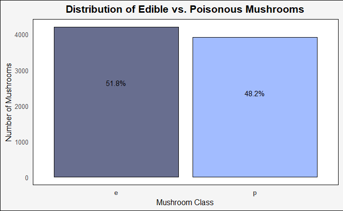

```r
library(ggplot2)

ggplot(mushroom, aes(x = class)) +
  geom_bar(fill = c("#030e45", "#648fff"), color = "black", linewidth = 0.5, alpha = 0.6) +
  labs(
    title = "Distribution of Edible vs. Poisonous Mushrooms",
    x = "Mushroom Class",
    y = "Number of Mushrooms"
  ) +
  theme_minimal(base_size = 15) +
  theme(
    plot.title = element_text(hjust = 0.5, face = "bold", size = 16),
    axis.title.x = element_text(size = 12),
    axis.title.y = element_text(size = 12),
    axis.text.x = element_text(size = 10, face = "bold"),
    axis.text.y = element_text(size = 10),
    panel.grid.major = element_blank(),
    panel.grid.minor = element_blank(),
    panel.background = element_rect(fill = "white"),
    plot.background = element_rect(fill = "whitesmoke")
  ) +
  geom_text(stat = 'count', aes(label = scales::percent(..count../sum(..count..))), vjust = 10)
```

-> The dataset is balanced!

A next steo would be to check the correlation between categorical features and **poisonous** using a heatmap. However, correlations are not useful for categorical features. -> Cramer’s V is used as a measure of association for categorical data.

```r
cramerV <- function(x, y) {
  tab <- table(x, y)
  chi2 <- chisq.test(tab)$statistic
  n <- sum(tab)
  min_dim <- min(dim(tab)) - 1
  sqrt(chi2 / (n * min_dim))
}

cramer_matrix <- matrix(NA, nrow = ncol(mushroom) - 1, ncol = 1)
rownames(cramer_matrix) <- colnames(mushroom)[-1]
colnames(cramer_matrix) <- "Cramer's V"

for (i in 2:ncol(mushroom)) {
  cramer_matrix[i - 1, 1] <- cramerV(mushroom$class, mushroom[, i])
}
cramer_matrix <- as.data.frame(cramer_matrix)
head(cramer_matrix)
```

|  | Cramer's V |
| --- | --- |
| cap.shape | 0.2455713 |
| cap.surface | 0.1969245 |
| cap.color | 0.2184267 |
| bruises | 0.5012804 |
| odor | 0.9710055 |
| gill.spacing | 0.3480521 |

-> Create a barplot that shows the importance of each feature

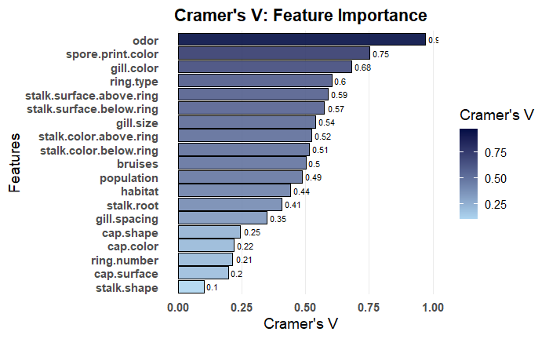

```r
ggplot(cramer_matrix, aes(x = reorder(rownames(cramer_matrix), `Cramer's V`),
                          y = `Cramer's V`, fill = `Cramer's V`)) +
  geom_bar(stat = "identity", color = "black", alpha = 0.9) +
  coord_flip() +
  scale_fill_gradient(low = "#AED6F1", high = "#030e45") +
  labs(
    title = "Cramer's V: Feature Importance",
    x = "Features",
    y = "Cramer's V",
    fill = "Cramer's V"
  ) +
  theme_minimal(base_size = 14) +
  theme(
    plot.title = element_text(hjust = 0.5, face = "bold"),
    axis.text.y = element_text(face = "bold"),
    axis.text.x = element_text(face = "bold"),
    panel.grid.major.y = element_blank(),
    panel.grid.minor = element_blank()
  ) +
  geom_text(aes(label = round(`Cramer's V`, 2)), hjust = -0.2, size = 3)
```

Create the corresponding heatmap:

```r
library(ggcorrplot)
library(reshape2)
library(dplyr)
library(ggplot2)
# Create a correlation matrix (Cramer's V) for all pairs of categorical variables
cramer_matrix <- matrix(NA, nrow = ncol(mushroom), ncol = ncol(mushroom))  # Including 'class'
rownames(cramer_matrix) <- colnames(mushroom)
colnames(cramer_matrix) <- colnames(mushroom)

# Loop through each pair of variables to calculate Cramer's V
for (i in 1:ncol(mushroom)) {
  for (j in i:ncol(mushroom)) {
    cramer_matrix[i, j] <- cramerV(mushroom[, i], mushroom[, j])
    cramer_matrix[j, i] <- cramer_matrix[i, j]  # Symmetric matrix
  }
}
```

[output not shown]

[output cut: 211 more lines]

[output not shown]

```r
# Convert the matrix to a data frame
cramer_matrix_df <- as.data.frame(cramer_matrix)

# Pivot the data to a longer format for ggplot
cramer_matrix_melted <- cramer_matrix_df %>%
  rownames_to_column(var = "Variable1") %>%
  pivot_longer(cols = -Variable1, names_to = "Variable2", values_to = "CramersV")

# Check the structure of the melted data
str(cramer_matrix_melted)
```

```
tibble [400 × 3] (S3: tbl_df/tbl/data.frame)
 $ Variable1: chr [1:400] "class" "class" "class" "class" ...
 $ Variable2: chr [1:400] "class" "cap.shape" "cap.surface" "cap.color" ...
 $ CramersV : num [1:400] 1 0.246 0.197 0.218 0.501 ...
```

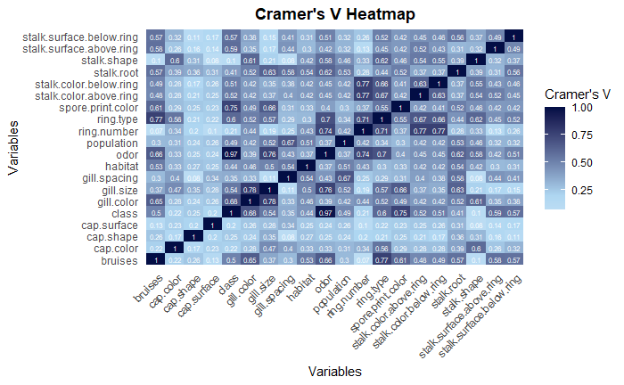

```r
# Plot the heatmap
ggplot(cramer_matrix_melted, aes(Variable1, Variable2, fill = CramersV)) +
  geom_tile() +
  scale_fill_gradient2(low = "white", high = "#030e45", mid = "#AED6F1", midpoint = 0.2) +
  geom_text(aes(label = round(CramersV, 2)), color = "white", size = 2) +
  theme_minimal() +
  labs(
    title = "Cramer's V Heatmap",
    x = "Variables",
    y = "Variables",
    fill = "Cramer's V"
  ) +
  theme(
    axis.text.x = element_text(angle = 45, vjust = 1, hjust = 1),
    plot.title = element_text(hjust = 0.5, face = "bold"),
    panel.grid.major = element_blank(),
    panel.grid.minor = element_blank()
  )
```

##Result

Given the two visualization it is easy to see that features like **odor**, **spore.print.color** and **gill.color** correlate with class.

Create barplots to check the distribution of the features for each class.

1. Relationship between class and spore print color

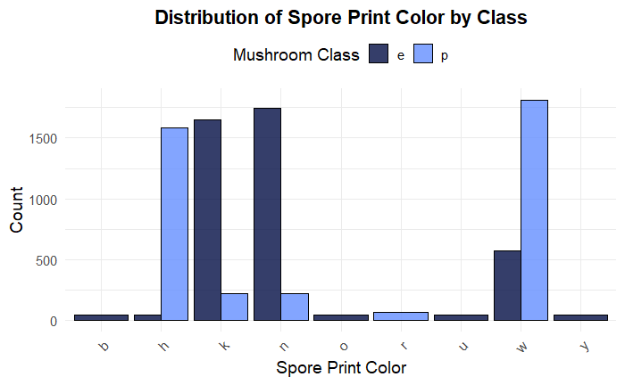

```r
ggplot(mushroom, aes(x = spore.print.color, fill = class)) +
  geom_bar(position = "dodge", color = "black", alpha = 0.8) +  # Add border & transparency
  scale_fill_manual(values = c("#030e45", "#648fff")) +  # Custom colors (red & green)
  labs(
    title = "Distribution of Spore Print Color by Class",
    x = "Spore Print Color",
    y = "Count",
    fill = "Mushroom Class"
  ) +
  theme_minimal(base_size = 14) +  # Larger font size
  theme(
    plot.title = element_text(hjust = 0.5, face = "bold"),  # Center title
    axis.text.x = element_text(angle = 45, vjust = 1, hjust = 1),  # Rotate x-axis labels
    legend.position = "top"  # Move legend to top
  )
```

2. Relationship between class and odor

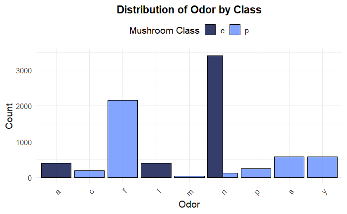

```r
ggplot(mushroom, aes(x = odor, fill = class)) +
  geom_bar(position = "dodge", color = "black", alpha = 0.8) +
  scale_fill_manual(values = c("#030e45", "#648fff")) +
  labs(
    title = "Distribution of Odor by Class",
    x = "Odor",
    y = "Count",
    fill = "Mushroom Class"
  ) +
  theme_minimal(base_size = 14) +
  theme(
    plot.title = element_text(hjust = 0.5, face = "bold"),
    axis.text.x = element_text(angle = 45, vjust = 1, hjust = 1),
    legend.position = "top"
  )
```

3. Relationship between class and gill.color

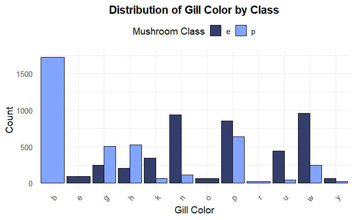

```r
ggplot(mushroom, aes(x = gill.color, fill = class)) +
  geom_bar(position = "dodge", color = "black", alpha = 0.8) +
  scale_fill_manual(values = c("#030e45", "#648fff")) +
  labs(
    title = "Distribution of Gill Color by Class",
    x = "Gill Color",
    y = "Count",
    fill = "Mushroom Class"
  ) +
  theme_minimal(base_size = 14) +
  theme(
    plot.title = element_text(hjust = 0.5, face = "bold"),
    axis.text.x = element_text(angle = 45, vjust = 1, hjust = 1),
    legend.position = "top"
  )
```

The plots demonstrate that these three classes are not evenly distributed and several categories only belong to edible or poisonous.